# Assignment 8/9

Alyson DeNittis

April 26, 2018

The data set we will use is called /data/mushroom_growth.csv. This was a fully-factorial experiment designed to find optimal temperatures for growing two species of mushrooms. I varied the levels of nitrogen (mg/g soil), light (hours per day),humidity (ambient vs high), and temperature (deg C). The response variable was growth rate (g/day).

Submit an R script that imports and analyzes this data, include code for a predictive model and meaningful plots.Look for what factors best predict high mushroom growth rates and back up your figures with statistical signifigance tests.

*Load Packages*

```r
library(ggplot2)
library(broom)
library(fitdistrplus)
library(tibble)
library(modelr)
library(gridExtra)
```

*Import Data*

```
## Observations: 216
## Variables: 6
## $ Species     <fct> P.ostreotus, P.ostreotus, P.ostreotus, P.ostreotus...
## $ Light       <int> 0, 10, 20, 0, 10, 20, 0, 10, 20, 0, 10, 20, 0, 10,...
## $ Nitrogen    <int> 0, 0, 0, 5, 5, 5, 10, 10, 10, 20, 20, 20, 25, 25, ...
## $ Humidity    <fct> Low, Low, Low, Low, Low, Low, Low, Low, Low, Low, ...
## $ Temperature <int> 20, 20, 20, 20, 20, 20, 20, 20, 20, 20, 20, 20, 20...
## $ GrowthRate  <dbl> 23.924, 34.132, 134.782, 44.516, 44.252, 81.080, 3...
```

*Check Fit*

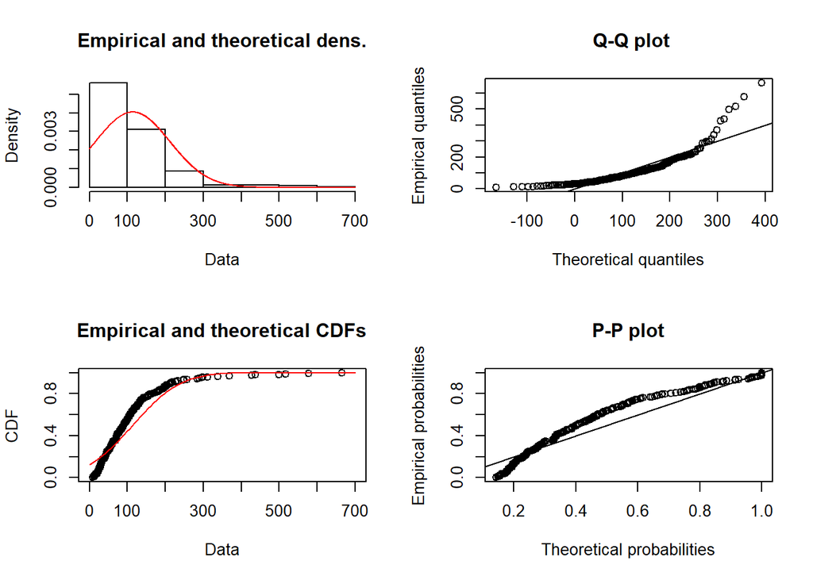

```r
plot(fitdist(df$GrowthRate, distr = "norm"))
```

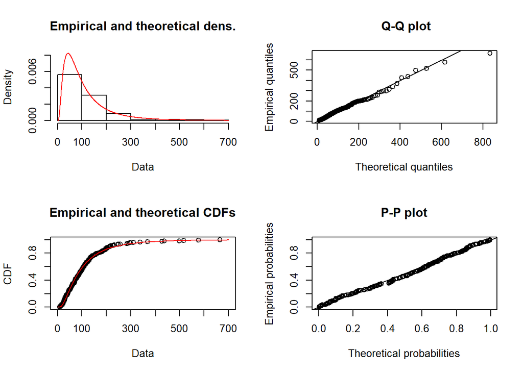

```r
plot(fitdist(df$GrowthRate, distr = "lnorm"))
```

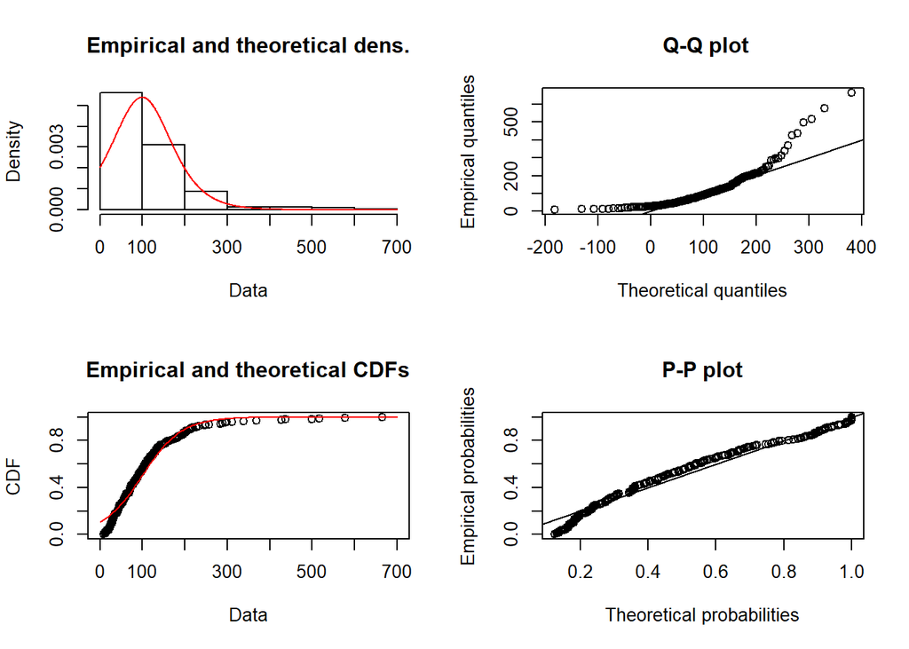

```r
plot(fitdist(df$GrowthRate, distr = "logis"))
```

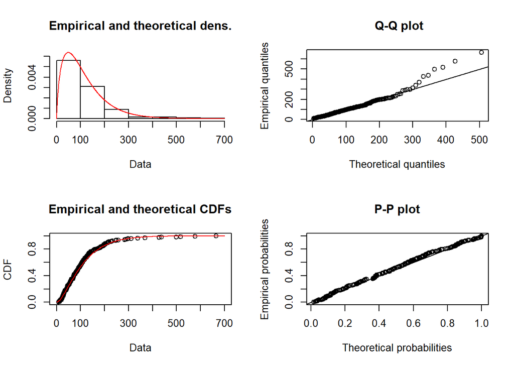

```r
plot(fitdist(df$GrowthRate, distr = "gamma"))
```

The following graph shows Nitrogen versus growth rate between high and low humidity. With a 95% confidence interval, there seems to be a difference between species at high humidity levels, but not in low levels.

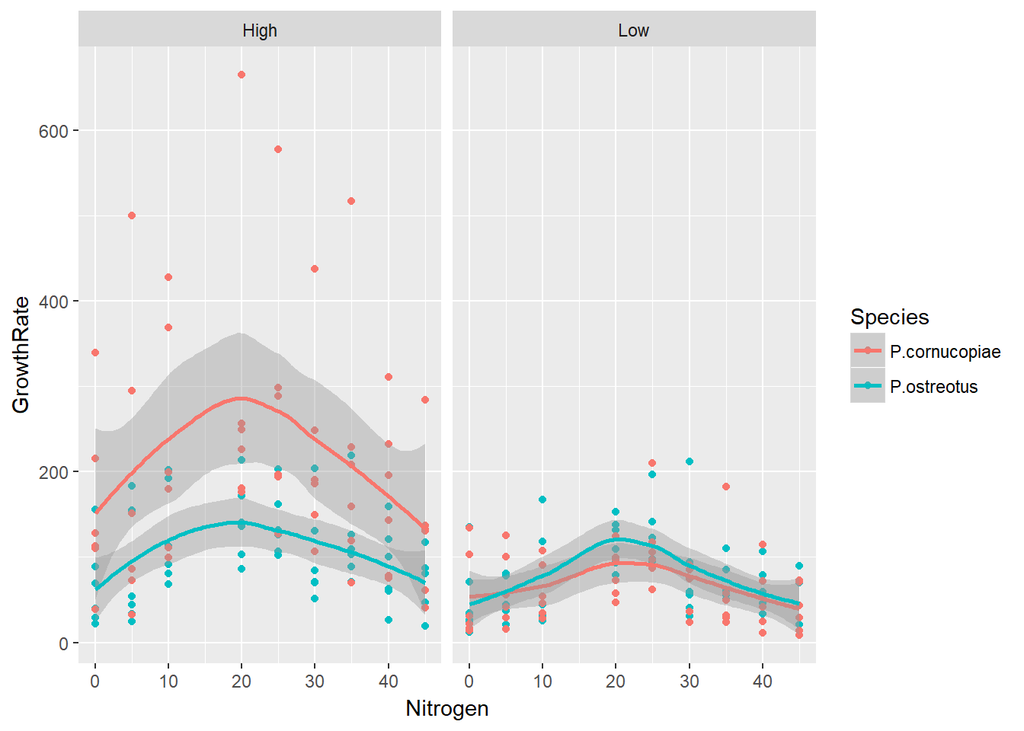

```r
ggplot(df, aes(x=Nitrogen, y=GrowthRate, col=Species))+
  geom_point() +
  stat_smooth()+
  facet_grid(facets = ~Humidity)
```

This can also be seen between light and growth rate between low and high humidity levels.

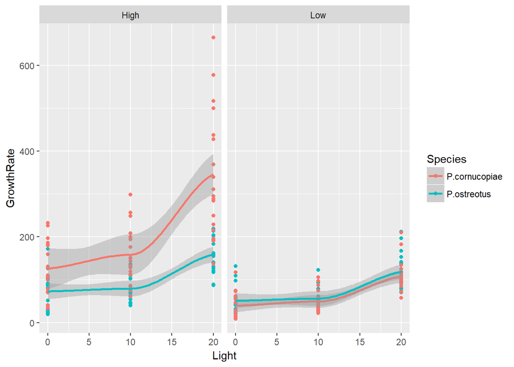

```r
ggplot(df, aes(x=Light, y=GrowthRate, col=Species))+
  geom_point() +
  stat_smooth()+
  facet_grid(facets = ~Humidity)
```

There seems to be a difference in species at high humidity, but should be tested using ANOVA models.In the following code, variables are chosen arbitrarily, as the order of variables can produce somewhat different results and are subject to bias.There are several variables that interact with each other and are statistically different at a level of significance of at least 0.01.Nitrogen does not seem to be significant in affecting growth rate.

```r
mod1 = aov(GrowthRate ~ Light*Species*Humidity*Nitrogen*Temperature, data = df)
summary(mod1)
```

```
##                                              Df Sum Sq Mean Sq F value
## Light                                         1 437624  437624 159.833
## Species                                       1 126397  126397  46.164
## Humidity                                      1 404774  404774 147.835
## Nitrogen                                      1   1197    1197   0.437
## Temperature                                   1  19900   19900   7.268
## Light:Species                                 1  40976   40976  14.966
## Light:Humidity                                1  65434   65434  23.898
## Species:Humidity                              1 181589  181589  66.321
## Light:Nitrogen                                1  14519   14519   5.303
## Species:Nitrogen                              1   1657    1657   0.605
## Humidity:Nitrogen                             1    339     339   0.124
## Light:Temperature                             1   8279    8279   3.024
## Species:Temperature                           1  39589   39589  14.459
## Humidity:Temperature                          1  31369   31369  11.457
## Nitrogen:Temperature                          1     36      36   0.013
## Light:Species:Humidity                        1  39713   39713  14.504
## Light:Species:Nitrogen                        1   2132    2132   0.779
## Light:Humidity:Nitrogen                       1   5715    5715   2.087
## Species:Humidity:Nitrogen                     1    309     309   0.113
## Light:Species:Temperature                     1   7593    7593   2.773
## Light:Humidity:Temperature                    1   4835    4835   1.766
## Species:Humidity:Temperature                  1 135972  135972  49.661
## Light:Nitrogen:Temperature                    1     66      66   0.024
## Species:Nitrogen:Temperature                  1   1258    1258   0.460
## Humidity:Nitrogen:Temperature                 1   1159    1159   0.423
## Light:Species:Humidity:Nitrogen               1   2030    2030   0.741
## Light:Species:Humidity:Temperature            1  20156   20156   7.362
## Light:Species:Nitrogen:Temperature            1    467     467   0.171
## Light:Humidity:Nitrogen:Temperature           1    413     413   0.151
## Species:Humidity:Nitrogen:Temperature         1   2067    2067   0.755
## Light:Species:Humidity:Nitrogen:Temperature   1     77      77   0.028
## Residuals                                   184 503794    2738
##                                               Pr(>F)
## Light                                        < 2e-16 ***
## Species                                     1.46e-10 ***
## Humidity                                     < 2e-16 ***
## Nitrogen                                    0.509346
## Temperature                                 0.007670 **
## Light:Species                               0.000152 ***
```

[output cut: 13 more lines]

```
## Light:Species:Temperature                   0.097565 .
## Light:Humidity:Temperature                  0.185540
## Species:Humidity:Temperature                3.55e-11 ***
## Light:Nitrogen:Temperature                  0.876777
## Species:Nitrogen:Temperature                0.498664
## Humidity:Nitrogen:Temperature               0.516106
## Light:Species:Humidity:Nitrogen             0.390317
## Light:Species:Humidity:Temperature          0.007296 **
## Light:Species:Nitrogen:Temperature          0.680103
## Light:Humidity:Nitrogen:Temperature         0.698191
## Species:Humidity:Nitrogen:Temperature       0.386013
## Light:Species:Humidity:Nitrogen:Temperature 0.867320
## Residuals
## ---
## Signif. codes:  0 '***' 0.001 '**' 0.01 '*' 0.05 '.' 0.1 ' ' 1
```

The species are subset to analyze separately.

```r
pc = subset(df, Species == "P.cornucopiae")
po = subset(df, Species == "P.ostreotus")
```

The following models show that light, humidity, and temperature all interact significantl for both species.

```r
pcmod2 = aov(GrowthRate ~ Light*Humidity, data = pc)
pcmod3 = aov(GrowthRate ~ Light*Humidity*Temperature, data = pc)
summary(pcmod2)
```

```
##                 Df Sum Sq Mean Sq F value   Pr(>F)
## Light            1 373212  373212   60.93 4.88e-12 ***
## Humidity         1 564294  564294   92.12 5.33e-16 ***
## Light:Humidity   1 103550  103550   16.90 7.87e-05 ***
## Residuals      104 637066    6126
## ---
## Signif. codes:  0 '***' 0.001 '**' 0.01 '*' 0.05 '.' 0.1 ' ' 1
```

```r
summary(pcmod3)
```

```
##                             Df Sum Sq Mean Sq F value   Pr(>F)
## Light                        1 373212  373212  95.197 3.38e-16 ***
## Humidity                     1 564294  564294 143.938  < 2e-16 ***
## Temperature                  1  57813   57813  14.747 0.000216 ***
## Light:Humidity               1 103550  103550  26.413 1.37e-06 ***
## Light:Temperature            1  15865   15865   4.047 0.046949 *
## Humidity:Temperature         1 148980  148980  38.001 1.50e-08 ***
## Light:Humidity:Temperature   1  22368   22368   5.705 0.018789 *
## Residuals                  100 392041    3920
## ---
## Signif. codes:  0 '***' 0.001 '**' 0.01 '*' 0.05 '.' 0.1 ' ' 1
```

```r
pomod2 = aov(GrowthRate ~ Light*Humidity, data = po)
pomod3 = aov(GrowthRate ~ Light*Humidity*Temperature, data = po)
summary(pcmod2)
```

```
##                 Df Sum Sq Mean Sq F value   Pr(>F)
## Light            1 373212  373212   60.93 4.88e-12 ***
## Humidity         1 564294  564294   92.12 5.33e-16 ***
## Light:Humidity   1 103550  103550   16.90 7.87e-05 ***
## Residuals      104 637066    6126
## ---
## Signif. codes:  0 '***' 0.001 '**' 0.01 '*' 0.05 '.' 0.1 ' ' 1
```

```r
summary(pcmod3)
```

```
##                             Df Sum Sq Mean Sq F value   Pr(>F)
## Light                        1 373212  373212  95.197 3.38e-16 ***
## Humidity                     1 564294  564294 143.938  < 2e-16 ***
## Temperature                  1  57813   57813  14.747 0.000216 ***
## Light:Humidity               1 103550  103550  26.413 1.37e-06 ***
## Light:Temperature            1  15865   15865   4.047 0.046949 *
## Humidity:Temperature         1 148980  148980  38.001 1.50e-08 ***
## Light:Humidity:Temperature   1  22368   22368   5.705 0.018789 *
## Residuals                  100 392041    3920
## ---
## Signif. codes:  0 '***' 0.001 '**' 0.01 '*' 0.05 '.' 0.1 ' ' 1
```

Predictions can be evaluated for each of the models.

```r
pcmod2pred = add_predictions(pc, model = pcmod2)
pcmod3pred = add_predictions(pc, model = pcmod3)
pomod2pred = add_predictions(po, model = pomod2)
pomod3pred = add_predictions(po, model = pomod3)
```

```r
mean((pcmod2pred$pred-pcmod2pred$GrowthRate)^2)
```

```
## [1] 5898.758
```

```r
mean((pcmod3pred$pred-pcmod3pred$GrowthRate)^2)
```

```
## [1] 3630.006
```

```r
mean((pomod2pred$pred-pomod2pred$GrowthRate)^2)
```

```
## [1] 1554.291
```

```r
mean((pomod3pred$pred-pomod3pred$GrowthRate)^2)
```

```
## [1] 1344.396
```

An ANOVA is run between the models, as well a Tukey test to determine the difference of means between groups.

```r
anova(pcmod2, pcmod3)
```

```
## Analysis of Variance Table
##
## Model 1: GrowthRate ~ Light * Humidity
## Model 2: GrowthRate ~ Light * Humidity * Temperature
##   Res.Df    RSS Df Sum of Sq      F    Pr(>F)
## 1    104 637066
## 2    100 392041  4    245025 15.625 5.799e-10 ***
## ---
## Signif. codes:  0 '***' 0.001 '**' 0.01 '*' 0.05 '.' 0.1 ' ' 1
```

```r
anova(pomod2, pomod3)
```

```
## Analysis of Variance Table
##
## Model 1: GrowthRate ~ Light * Humidity
## Model 2: GrowthRate ~ Light * Humidity * Temperature
##   Res.Df    RSS Df Sum of Sq      F   Pr(>F)
## 1    104 167863
## 2    100 145195  4     22669 3.9031 0.005485 **
## ---
## Signif. codes:  0 '***' 0.001 '**' 0.01 '*' 0.05 '.' 0.1 ' ' 1
```

```r
pcmod4 = aov(GrowthRate ~ factor(Light)*Humidity*factor(Temperature), data = pc)
TukeyHSD(pcmod4)
```

```
##   Tukey multiple comparisons of means
##     95% family-wise confidence level
##
## Fit: aov(formula = GrowthRate ~ factor(Light) * Humidity * factor(Temperature), data = pc)
##
## $`factor(Light)`
##            diff       lwr       upr    p adj
## 10-0   21.09302 -10.09145  52.27748 0.246266
## 20-0  143.99302 112.80855 175.17748 0.000000
## 20-10 122.90000  91.71554 154.08446 0.000000
##
## $Humidity
##               diff       lwr      upr p adj
## Low-High -144.5676 -165.7982 -123.337     0
##
## $`factor(Temperature)`
##            diff       lwr       upr    p adj
## 25-20 -46.27336 -67.50395 -25.04277 3.71e-05
##
## $`factor(Light):Humidity`
##                        diff         lwr         upr     p adj
## 10:High-0:High    32.296972  -21.576296   86.170240 0.5069849
## 20:High-0:High   219.839938  165.966670  273.713206 0.0000000
## 0:Low-0:High     -86.533691 -140.406959  -32.660422 0.0001393
## 10:Low-0:High    -76.644630 -130.517898  -22.771361 0.0010388
## 20:Low-0:High    -18.387596  -72.260864   35.485672 0.9192712
## 20:High-10:High  187.542966  133.669698  241.416234 0.0000000
## 0:Low-10:High   -118.830663 -172.703931  -64.957395 0.0000001
## 10:Low-10:High  -108.941602 -162.814870  -55.068334 0.0000009
## 20:Low-10:High   -50.684569 -104.557837    3.188699 0.0774871
## 0:Low-20:High   -306.373629 -360.246897 -252.500361 0.0000000
## 10:Low-20:High  -296.484568 -350.357836 -242.611300 0.0000000
## 20:Low-20:High  -238.227535 -292.100803 -184.354267 0.0000000
## 10:Low-0:Low       9.889061  -43.984207   63.762329 0.9946491
## 20:Low-0:Low      68.146094   14.272826  122.019362 0.0050576
## 20:Low-10:Low     58.257033    4.383765  112.130301 0.0261304
##
## $`factor(Light):factor(Temperature)`
##                    diff        lwr         upr     p adj
## 10:20-0:20    20.533920  -33.33935   74.407188 0.8767886
```

[output cut: 77 more lines]

```
## 10:High:25-0:High:25    36.157334  -51.6117253  123.926392 0.9646330
## 20:High:25-0:High:25   154.900945   67.1318858  242.670004 0.0000033
## 0:Low:25-0:High:25     -33.551898 -121.3209566   54.217161 0.9796875
## 10:Low:25-0:High:25    -26.405004 -114.1740627   61.364055 0.9971859
## 20:Low:25-0:High:25     40.157505  -47.6115541  127.926564 0.9275212
## 20:High:25-10:High:25  118.743611   30.9745522  206.512670 0.0009785
## 0:Low:25-10:High:25    -69.709231 -157.4782902   18.059828 0.2621183
## 10:Low:25-10:High:25   -62.562337 -150.3313962   25.206722 0.4242081
## 20:Low:25-10:High:25     4.000171  -83.7688877   91.769230 1.0000000
## 0:Low:25-20:High:25   -188.452842 -276.2219013 -100.683784 0.0000000
## 10:Low:25-20:High:25  -181.305948 -269.0750074  -93.536890 0.0000000
## 20:Low:25-20:High:25  -114.743440 -202.5124988  -26.974381 0.0017265
## 10:Low:25-0:Low:25       7.146894  -80.6221649   94.915953 1.0000000
## 20:Low:25-0:Low:25      73.709402  -14.0596564  161.478461 0.1911822
## 20:Low:25-10:Low:25     66.562509  -21.2065504  154.331567 0.3283823
```

```r
pomod4 = aov(GrowthRate ~ factor(Light)*Humidity*factor(Temperature), data = po)
TukeyHSD(pomod4)
```

```
##   Tukey multiple comparisons of means
##     95% family-wise confidence level
##
## Fit: aov(formula = GrowthRate ~ factor(Light) * Humidity * factor(Temperature), data = po)
##
## $`factor(Light)`
##            diff       lwr      upr    p adj
## 10-0   5.572542 -14.11841 25.26350 0.779307
## 20-0  76.517556  56.82660 96.20851 0.000000
## 20-10 70.945014  51.25406 90.63597 0.000000
##
## $Humidity
##               diff      lwr       upr    p adj
## Low-High -28.58906 -41.9948 -15.18333 5.28e-05
##
## $`factor(Temperature)`
##           diff       lwr      upr     p adj
## 25-20 7.879602 -5.526131 21.28534 0.2462091
##
## $`factor(Light):Humidity`
##                        diff         lwr        upr     p adj
## 10:High-0:High     6.280528  -27.736924  40.297980 0.9945024
## 20:High-0:High    85.937333   51.919882 119.954785 0.0000000
## 0:Low-0:High     -21.837222  -55.854674  12.180230 0.4287795
## 10:Low-0:High    -16.972667  -50.990118  17.044785 0.6958663
## 20:Low-0:High     45.260556   11.243104  79.278007 0.0026660
## 20:High-10:High   79.656806   45.639354 113.674257 0.0000000
## 0:Low-10:High    -28.117750  -62.135202   5.899702 0.1653302
## 10:Low-10:High   -23.253194  -57.270646  10.764257 0.3568793
## 20:Low-10:High    38.980028    4.962576  72.997480 0.0150708
## 0:Low-20:High   -107.774556 -141.792007 -73.757104 0.0000000
## 10:Low-20:High  -102.910000 -136.927452 -68.892548 0.0000000
## 20:Low-20:High   -40.676778  -74.694230  -6.659326 0.0096492
## 10:Low-0:Low       4.864556  -29.152896  38.882007 0.9983628
## 20:Low-0:Low      67.097778   33.080326 101.115230 0.0000017
## 20:Low-10:Low     62.233222   28.215770  96.250674 0.0000099
##
## $`factor(Light):factor(Temperature)`
##                   diff        lwr       upr     p adj
## 10:20-0:20    7.226083  -26.79137  41.24354 0.9894879
```

[output cut: 77 more lines]

```
## 10:High:25-0:High:25     4.528000  -50.892431  59.948431 1.0000000
## 20:High:25-0:High:25    97.368000   41.947569 152.788431 0.0000037
## 0:Low:25-0:High:25     -39.932000  -95.352431  15.488431 0.4071973
## 10:Low:25-0:High:25    -36.622000  -92.042431  18.798431 0.5440773
## 20:Low:25-0:High:25     14.450000  -40.970431  69.870431 0.9992305
## 20:High:25-10:High:25   92.840000   37.419569 148.260431 0.0000122
## 0:Low:25-10:High:25    -44.460000  -99.880431  10.960431 0.2485736
## 10:Low:25-10:High:25   -41.150000  -96.570431  14.270431 0.3604343
## 20:Low:25-10:High:25     9.922000  -45.498431  65.342431 0.9999806
## 0:Low:25-20:High:25   -137.300000 -192.720431 -81.879569 0.0000000
## 10:Low:25-20:High:25  -133.990000 -189.410431 -78.569569 0.0000000
## 20:Low:25-20:High:25   -82.918000 -138.338431 -27.497569 0.0001500
## 10:Low:25-0:Low:25       3.310000  -52.110431  58.730431 1.0000000
## 20:Low:25-0:Low:25      54.382000   -1.038431 109.802431 0.0594985
## 20:Low:25-10:Low:25     51.072000   -4.348431 106.492431 0.1006276
```

The results from the Tukey test can be reflected in the graphs below. From this we can see that light, temperature, and humidity impact growth.

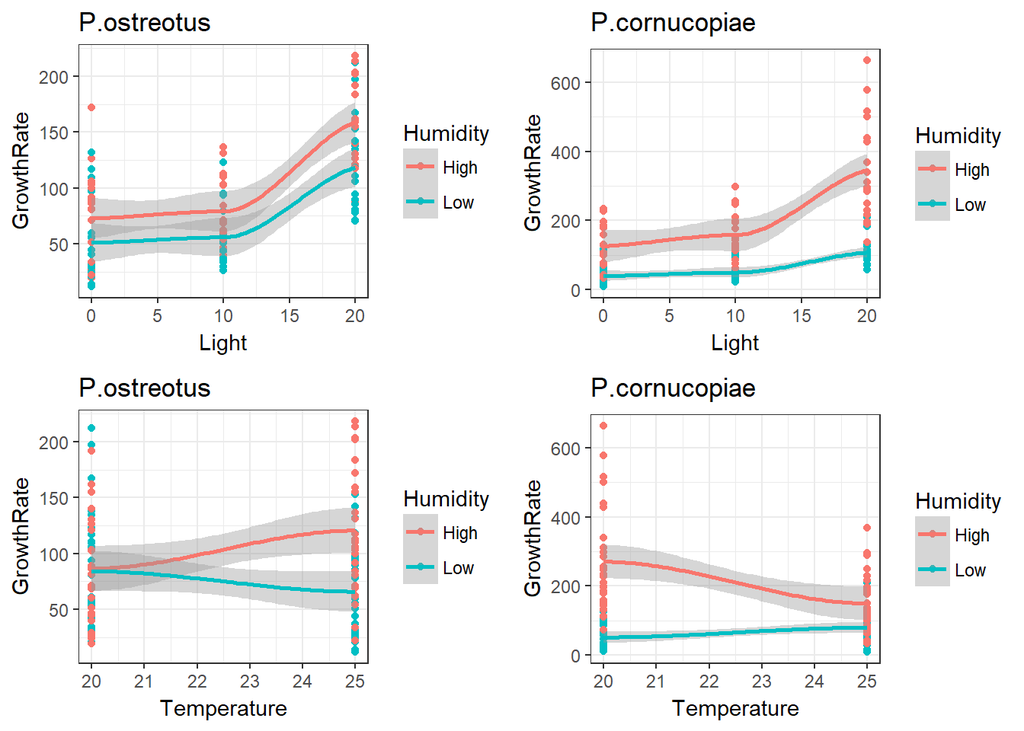

```r
poplot1 = ggplot(po, aes(x=Light,y=GrowthRate,col=Humidity)) +
  geom_point() +
  stat_smooth() +
  theme_bw() +
  ggtitle("P.ostreotus")

pcplot1 = ggplot(pc, aes(x=Light,y=GrowthRate,col=Humidity)) +
  geom_point() +
  stat_smooth() +
  theme_bw() +
  ggtitle("P.cornucopiae")

poplot2 = ggplot(po, aes(x=Temperature,y=GrowthRate,col=Humidity)) +
  geom_point() +
  stat_smooth() +
  theme_bw() +
  ggtitle("P.ostreotus")

pcplot2 = ggplot(pc, aes(x=Temperature,y=GrowthRate,col=Humidity)) +
  geom_point() +
  stat_smooth() +
  theme_bw() +
  ggtitle("P.cornucopiae")

grid.arrange(poplot1,pcplot1, poplot2, pcplot2)
```

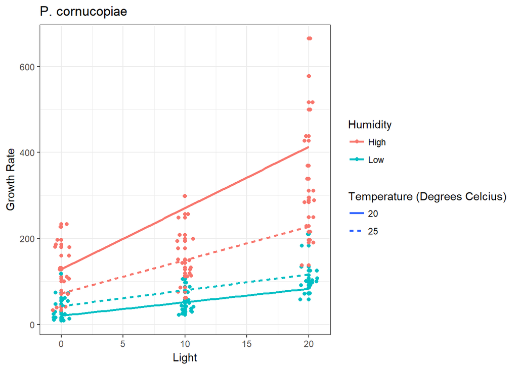

```r
ggplot(pc, aes(x=Light, y=GrowthRate, col = Humidity, linetype = factor(Temperature)))+
  geom_jitter(width = .7 )+
  geom_point()+
  labs(y="Growth Rate", title = "P. cornucopiae")+
  scale_linetype_discrete(name = "Temperature (Degrees Celcius)")+
  stat_smooth(method = "lm", se = FALSE)+
  theme_bw()
```

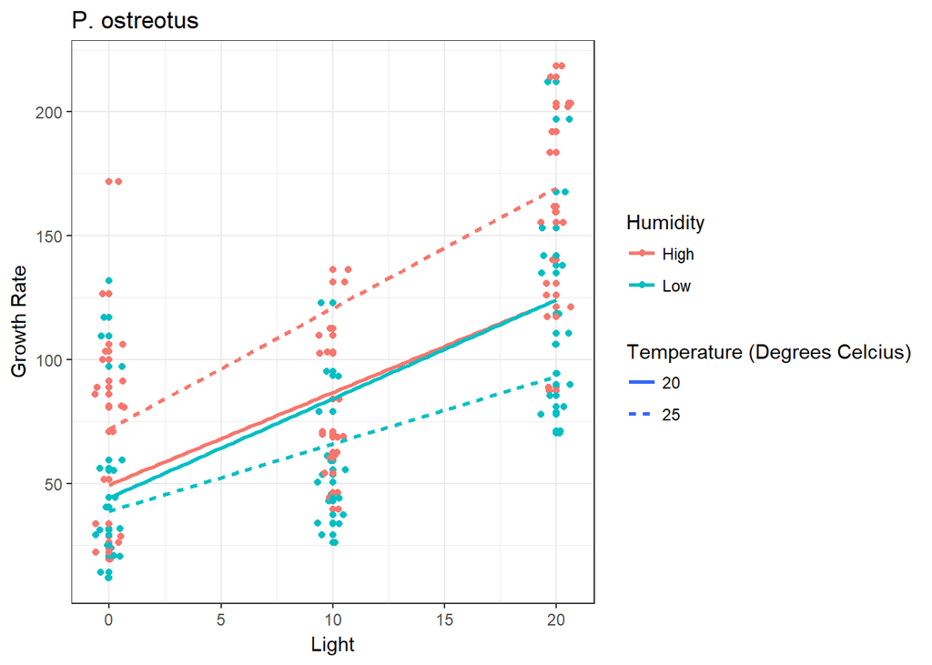

```r
ggplot(po, aes(x=Light, y=GrowthRate, col = Humidity, linetype = factor(Temperature)))+
  geom_jitter(width = .7 )+
  geom_point()+
  labs(y="Growth Rate", title = "P. ostreotus")+
  scale_linetype_discrete(name = "Temperature (Degrees Celcius)")+
  stat_smooth(method = "lm", se = FALSE)+
  theme_bw()
```